# Biostatistics - Bioinformatics for Computational Genomics

Final Examination Template

Professor: Francesca Ieva | Teaching Assistant: Stefania Colombo

Academic Year 2025/2026

# Student Information

| Field | Information |
| --- | --- |
| **Name** | TIZIANO |
| **Surname** | MARSIGLIANI |
| **Student ID (Matricola)** | 301821 |
| **Personal Code** | 10808414 |

# Instructions

- Answer **only the two assigned questions**
- Clearly justify all methodological choices
- Report relevant statistical results
- Provide biological and clinical interpretation of findings
- Include comments directly below each code chunk

# Initial Setup

## 1. Load Required Libraries

```r
library(survival)
library(survminer)
library(insight)
library(lattice)
library(lme4)
```

## 2. Load the Dataset

```r
load("multiomics_study.RData")

patients <- final_data$patients
genotypes <- final_data$genotypes
snp_info <- final_data$snp_info
biomarker_data <- final_data$biomarker_data
```

## 3. Preliminary Data Inspection

```r
str(patients)
```

```
## tibble [1,000 × 12] (S3: tbl_df/tbl/data.frame)
##  $ patient_id            : int [1:1000] 1 2 3 4 5 6 7 8 9 10 ...
##  $ sex                   : chr [1:1000] "male" "female" "male" "male" ...
##  $ age                   : num [1:1000] 44 57 22 46 59 54 41 57 39 53 ...
##  $ inflammatory_index    : num [1:1000] 6.4 8 6.4 3.6 2.6 4.1 6.2 4.3 4.6 7.1 ...
##  $ steroid_use           : int [1:1000] 1 0 0 1 1 1 0 0 0 0 ...
##  $ prior_relapse         : int [1:1000] 0 1 1 0 0 0 1 0 0 1 ...
##  $ treatment_arm         : chr [1:1000] "standard" "biologic" "standard" "standard" ...
##  $ center                : chr [1:1000] "Center_A" "Center_C" "Center_C" "Center_A" ...
##  $ time_to_flare         : num [1:1000] 8.593 0.792 2.901 1.782 1.358 ...
##  $ time_to_complication  : num [1:1000] 9.68 4.77 12.71 6.54 4.7 ...
##  $ time_to_severe_outcome: num [1:1000] 10 7.37 10 7.51 5.83 ...
##  $ outcome_type          : chr [1:1000] "censored" "hospitalization" "censored" "hospitalization" ...
```

```r
str(genotypes)
```

```
## 'data.frame':    1000 obs. of  736 variables:
##  $ locus_1_snp_1  : int  2 0 0 2 1 0 1 1 0 1 ...
##  $ locus_1_snp_2  : int  2 1 0 1 0 0 0 1 1 2 ...
##  $ locus_1_snp_3  : int  0 0 0 1 0 0 0 0 0 0 ...
##  $ locus_1_snp_4  : int  0 1 1 0 0 0 0 0 0 0 ...
##  $ locus_1_snp_5  : int  0 0 0 2 0 0 0 0 0 0 ...
##  $ locus_1_snp_6  : int  1 1 0 0 0 0 0 0 1 0 ...
##  $ locus_1_snp_7  : int  0 0 2 1 1 0 1 0 1 0 ...
##  $ locus_1_snp_8  : int  0 0 1 1 1 2 0 0 0 0 ...
##  $ locus_1_snp_9  : int  0 0 1 0 2 1 0 0 0 1 ...
##  $ locus_1_snp_10 : int  2 0 1 1 0 0 0 1 0 0 ...
##  $ locus_1_snp_11 : int  0 0 0 1 0 0 1 1 1 0 ...
##  $ locus_1_snp_12 : int  0 1 2 2 1 1 0 0 1 2 ...
##  $ locus_1_snp_13 : int  0 0 1 1 1 1 2 0 1 1 ...
##  $ locus_1_snp_14 : int  0 0 0 0 0 0 0 0 0 0 ...
```

[output cut: 86 more lines]

```r
str(snp_info)
```

```
## 'data.frame':    735 obs. of  4 variables:
##  $ locus     : chr  "locus_1" "locus_1" "locus_1" "locus_1" ...
##  $ locus_type: chr  "metabolic" "metabolic" "metabolic" "metabolic" ...
##  $ snp_id    : chr  "locus_1_snp_1" "locus_1_snp_2" "locus_1_snp_3" "locus_1_snp_4" ...
##  $ effect    : chr  "flare" "flare" "flare" "flare" ...
```

```r
str(biomarker_data)
```

```
## tibble [54,708 × 4] (S3: tbl_df/tbl/data.frame)
##  $ patient_id: int [1:54708] 1 1 1 1 1 1 1 1 1 1 ...
##  $ time      : num [1:54708] 2.95 2.95 2.95 2.95 2.95 ...
##  $ biomarker : chr [1:54708] "cytokine_1" "cytokine_2" "cytokine_3" "cytokine_4" ...
##  $ value     : num [1:54708] 12.32 5.26 4.91 8.95 8.49 ...
```

# Question 1

## Assigned Exercise

#### **Question 8:**

> Define a binary outcome corresponding to the occurrence of a severe disease activity within 5 years (hospitalization or treatment failure). Exclude patients who are censored before 5 years.
> 1. Construct a `cytokine_activity_score` by combining all baseline cytokine measurements and clearly describe the strategy used (e.g., mean expression, sum, …).
> 2. Fit a logistic regression model including:
>    - age
>    - sex
>    - cytokine activity score
>    - inflammatory index
>    - steroid use
>    - prior relapse
> 3. Fit a mixed-effects logistic regression model including:
>    - same fixed effects as above
>    - random intercept for center.
> 4. Compare the two models in terms of:
>    - model fit (AIC or likelihood)
>    - interpretation of fixed effects.
> 5. Quantify and interpret the variability attributable to differences between centers.

## Step 1

```r
censored <- patients$outcome_type == "censored" &
            patients$time_to_severe_outcome < 5
filtered <- patients[!censored, ]
filtered$severe_event_5y <- ifelse(filtered$outcome_type %in%
                                  c("hospitalization","treatment_failure")
                                  &filtered$time_to_severe_outcome <= 5, 1, 0)

cat("Excluded (censored before 5y):", sum(censored), "of", nrow(patients), "\n")
```

```
## Excluded (censored before 5y): 0 of 1000
```

There are no censored patients before the 5th year.

```r
cat("Occurrence of a severe disease activity within 5 years (hospitalization or treatment failure)")
```

```
## Occurrence of a severe disease activity within 5 years (hospitalization or treatment failure)
```

```r
table(filtered$severe_event_5y)
```

```
##
##   0   1
## 690 310
```

```r
baseline_c <- data.frame(patient_id = numeric(),
                         Baseline_Time = character(),
                         Raw_Score = numeric())

for(id in unique(biomarker_data$patient_id))
  {single_patient <- data.frame(biomarker_data[biomarker_data$patient_id==id,])
   time_breaks <- levels(factor(single_patient$time))
   baseline_time <- min(time_breaks)               #extract the min time control
   score <- mean(single_patient[single_patient$time==baseline_time,]$value,
                              na.rm = TRUE)        #ignoring NA values
   insertion <- data.frame(patient_id=id, Baseline_Time=baseline_time, Raw_Score=score)
   baseline_c <- rbind(baseline_c,insertion)}

head(baseline_c,n=20)
```

|  | patient_id | Baseline_Time | Raw_Score |
| --- | --- | --- | --- |
| 1 | 1 | 2.94656471349299 | 8.186866 |
| 2 | 2 | 0.668776171256518 | 8.502883 |
| 3 | 3 | 0.20698752719909 | 7.821582 |
| 4 | 4 | 1.72198559193682 | 9.036020 |
| 5 | 5 | 0.969967716581567 | 7.696006 |
| 6 | 6 | 3.40942620067917 | 8.300007 |
| 7 | 7 | 0.450502761391358 | 7.676894 |
| 8 | 8 | 0.504511030120927 | 8.409672 |
| 9 | 9 | 1.94654286606237 | 7.484702 |
| 10 | 10 | 0.671901640233913 | 9.408215 |

[output cut: 10 more lines]

```r
raw_score <- baseline_c$Raw_Score

cytokine_activity_score <- (raw_score - mean(raw_score))/sd(raw_score)
cytokine_activity_score <- round(cytokine_activity_score, digits = 4)

cytokine_activity_score
```

```
##    [1] -0.4132  0.0961 -1.0018  0.9552 -1.2042 -0.2309 -1.2350 -0.0542 -1.5447
##   [10]  1.5550 -0.5983 -0.5396  0.4080 -1.6034 -2.2253 -0.1255  0.5981 -0.1716
##   [19]  0.6826  0.2960 -0.5912 -0.1736 -0.1026 -0.1596  0.4428 -1.8762  1.3077
##   [28] -1.1593  1.0322  1.3696  1.2030  0.2440  1.0101 -0.4496  0.2097 -0.8054
##   [37]  1.8601  0.2164  0.2711 -0.0924  0.9302  0.5931 -1.2985  0.9020  0.2430
##   [46]  1.9067 -1.1265 -1.5821 -1.4744 -0.6398 -0.0345 -1.0890 -0.2846 -1.4390
##   [55]  1.6135 -0.5040  0.4859  0.8866  0.2022  1.7153 -0.2622 -0.0887 -0.8455
##   [64]  2.5238  0.9905 -0.2082 -1.2143 -0.8928  0.1547 -0.6477 -1.3672 -1.4242
##   [73]  0.0841  0.2719 -0.6841 -1.1313 -1.4103 -0.4715  0.4643  0.2052  0.3904
##   [82]  0.6060 -0.5225 -0.9384 -0.9225  0.7360 -0.2358 -1.9937  0.4456  1.4003
##   [91]  0.8387 -0.4943 -0.2263 -0.7726 -0.0643  0.0148  0.6920 -2.0877  0.2500
##  [100] -0.6539  0.0314 -0.6567  0.2617  0.2270  0.2548  0.4431  0.9993  0.2592
##  [109] -0.1366  2.7507  0.3958 -0.0742 -0.2452 -0.1189  0.9777  0.1921 -1.3499
##  [118]  0.0160 -0.8711  1.3387  1.4040  2.2807 -2.6514  0.5925 -1.0721 -0.1678
##  [127] -1.0237  0.3065 -1.9250 -0.4424  0.0790 -1.1536  0.5165  0.7147 -0.5290
```

[output cut: 97 more lines]

```r
summary(cytokine_activity_score)
```

```
##       Min.    1st Qu.     Median       Mean    3rd Qu.       Max.
## -2.6514000 -0.6716500 -0.0518500  0.0000011  0.6493750  3.5623000
```

To construct the `cytokine_activity_score`, the **mean expression** of the 12 cytokines was computed at each patient’s initial observation. To enable a standardized comparison across the cohort, the final patient averages were then **transformed into Z scores**.

$$z = \frac{x - \mu}{\sigma}$$

Although the chronological time of the first measurement varied between individuals, all subjects were captured at their respective entry point into the study.

### Interpretation

Treating each patient’s first available record as the one referred to the *same baseline time*, the cohort was considered homogeneous. This strategy yields to a standardized, composite index (mean = 0, SD = 1) that represents the relative cytokine upregulation or downregulation of each patient compared to the collective cohort mean.

## Step 2

```r
str(filtered)
```

```
## tibble [1,000 × 13] (S3: tbl_df/tbl/data.frame)
##  $ patient_id            : int [1:1000] 1 2 3 4 5 6 7 8 9 10 ...
##  $ sex                   : chr [1:1000] "male" "female" "male" "male" ...
##  $ age                   : num [1:1000] 44 57 22 46 59 54 41 57 39 53 ...
##  $ inflammatory_index    : num [1:1000] 6.4 8 6.4 3.6 2.6 4.1 6.2 4.3 4.6 7.1 ...
##  $ steroid_use           : int [1:1000] 1 0 0 1 1 1 0 0 0 0 ...
##  $ prior_relapse         : int [1:1000] 0 1 1 0 0 0 1 0 0 1 ...
##  $ treatment_arm         : chr [1:1000] "standard" "biologic" "standard" "standard" ...
##  $ center                : chr [1:1000] "Center_A" "Center_C" "Center_C" "Center_A" ...
##  $ time_to_flare         : num [1:1000] 8.593 0.792 2.901 1.782 1.358 ...
##  $ time_to_complication  : num [1:1000] 9.68 4.77 12.71 6.54 4.7 ...
##  $ time_to_severe_outcome: num [1:1000] 10 7.37 10 7.51 5.83 ...
##  $ outcome_type          : chr [1:1000] "censored" "hospitalization" "censored" "hospitalization" ...
##  $ severe_event_5y       : num [1:1000] 0 0 0 0 0 0 0 1 0 0 ...
```

```r
filtered$sex <- factor(filtered$sex, labels=c("female","male"))
filtered$outcome_type <- factor(filtered$outcome_type,
                    labels=c("censored","hospitalization","treatment_failure"))
df <- cbind(filtered, cytokine_activity_score)

mod.df <- glm(severe_event_5y ~ age + sex + cytokine_activity_score
               + inflammatory_index + steroid_use + prior_relapse,
               family=binomial(link=logit), data = df)
summary(mod.df)
```

```
##
## Call:
## glm(formula = severe_event_5y ~ age + sex + cytokine_activity_score +
##     inflammatory_index + steroid_use + prior_relapse, family = binomial(link = logit),
##     data = df)
##
## Coefficients:
##                          Estimate Std. Error z value Pr(>|z|)
## (Intercept)             -4.177929   0.430415  -9.707  < 2e-16 ***
## age                      0.038015   0.005764   6.596 4.23e-11 ***
## sexmale                 -0.010990   0.144178  -0.076  0.93924
## cytokine_activity_score -0.159684   0.072948  -2.189  0.02860 *
## inflammatory_index       0.216461   0.041733   5.187 2.14e-07 ***
## steroid_use              0.133881   0.148884   0.899  0.36853
## prior_relapse            0.474633   0.144772   3.278  0.00104 **
## ---
## Signif. codes:  0 '***' 0.001 '**' 0.01 '*' 0.05 '.' 0.1 ' ' 1
##
## (Dispersion parameter for binomial family taken to be 1)
##
##     Null deviance: 1238.2  on 999  degrees of freedom
## Residual deviance: 1149.7  on 993  degrees of freedom
## AIC: 1163.7
##
## Number of Fisher Scoring iterations: 4
```

```r
OR_glm <- exp(cbind(OR = coef(mod.df), confint.default(mod.df)))
round(OR_glm, 4)
```

```
##                             OR  2.5 % 97.5 %
## (Intercept)             0.0153 0.0066 0.0356
## age                     1.0387 1.0271 1.0505
## sexmale                 0.9891 0.7456 1.3121
## cytokine_activity_score 0.8524 0.7389 0.9834
## inflammatory_index      1.2417 1.1442 1.3475
## steroid_use             1.1433 0.8539 1.5306
## prior_relapse           1.6074 1.2103 2.1348
```

### Interpretation

The logistic regression model identified many key predictors of severe events at 5 years. Advanced age, a higher baseline inflammatory index, and a history of prior relapse were all identified as highly significant, direct risk factors for a worse long-term prognosis. Conversely, sex and steroid use showed no statistically significant association with the 5-year outcome (p-value computation).

```r
CI.95 <- c(Lower= exp(-0.1597*10 - 1.96*10*0.0729), Upper = exp(-0.1597*10 + 1.96*10*0.0729))

cat("For an increment of 10 points in cytokine activity score (at baseline time), the risk of severe
activity desease decreases of about",exp(coef(mod.df)[4]*10), "times, with 95% CI = [", CI.95[1]," , ", CI.95[2],"]")
```

```
## For an increment of 10 points in cytokine activity score (at baseline time), the risk of severe
## activity desease decreases of about 0.202535 times, with 95% CI = [ 0.04851705  ,  0.8452186 ]
```

## Step 3

```r
df$center <- as.factor(df$center)

log_MEM <- glmer(severe_event_5y ~ age + sex + cytokine_activity_score
                 + inflammatory_index + steroid_use + prior_relapse + (1| center),
                 family=binomial, data=df)
summary(log_MEM)
```

```
## Generalized linear mixed model fit by maximum likelihood (Laplace
##   Approximation) [glmerMod]
##  Family: binomial  ( logit )
## Formula:
## severe_event_5y ~ age + sex + cytokine_activity_score + inflammatory_index +
##     steroid_use + prior_relapse + (1 | center)
##    Data: df
##
##       AIC       BIC    logLik -2*log(L)  df.resid
##    1159.2    1198.5    -571.6    1143.2       992
##
## Scaled residuals:
##     Min      1Q  Median      3Q     Max
## -1.6618 -0.6774 -0.4845  1.0100  3.1827
##
## Random effects:
##  Groups Name        Variance Std.Dev.
##  center (Intercept) 0.05563  0.2359
## Number of obs: 1000, groups:  center, 3
##
## Fixed effects:
##                          Estimate Std. Error z value Pr(>|z|)
## (Intercept)             -4.247817   0.454915  -9.338  < 2e-16 ***
## age                      0.038843   0.005822   6.671 2.53e-11 ***
## sexmale                 -0.017294   0.145052  -0.119 0.905095
## cytokine_activity_score -0.170058   0.073515  -2.313 0.020709 *
## inflammatory_index       0.215215   0.042030   5.120 3.05e-07 ***
## steroid_use              0.145678   0.149946   0.972 0.331282
## prior_relapse            0.508533   0.146285   3.476 0.000508 ***
## ---
## Signif. codes:  0 '***' 0.001 '**' 0.01 '*' 0.05 '.' 0.1 ' ' 1
##
## Correlation of Fixed Effects:
##             (Intr) age    sexmal cytk__ inflm_ strd_s
## age         -0.774
## sexmale     -0.202  0.075
## cytkn_ctvt_  0.014 -0.007  0.017
## inflmmtry_n -0.558  0.113 -0.044 -0.001
## steroid_use -0.140  0.024  0.002 -0.006  0.014
## prior_relps -0.185  0.051 -0.005 -0.002  0.029 -0.032
```

### Interpretation

The mixed-effects model accounts for the nested structure across the $3$ clinical centers, capturing a baseline center-to-center variance of **`0.0556`** (Std. Dev. = **`0.2359`**). The fixed effects remain stable compared to the standard logistic regression, confirming **age**, **inflammatory index**, and **prior relapse** as highly significant risk factors ($p < 0.001$).

Crucially, the `cytokine_activity_score` retains its significant protective effect ($\beta = -0.1701$, $p = 0.0207$), proving this trend is a robust feature independent of center-specific variations while variables such as `sexmale` and `steroid_use` remain statistically non-significant.

## Step 4

With the following **Likelihood Ratio Test (LRT)**, the comparison of the two models can be assessed via hypothesis testing:

$H_0$: Logistic Regression model (`mod.df`) is preferable.

$H_1$: Mixed Effects Logistic Regression model (`log_MEM`) is preferable;

```r
anova(log_MEM, mod.df, 'Chisq')
```

|  | npar | AIC | BIC | logLik | -2*log(L) | Chisq | Df | Pr(>Chisq) |
| --- | --- | --- | --- | --- | --- | --- | --- | --- |
| mod.df | 7 | 1163.675 | 1198.029 | -574.8375 | 1149.675 | NA | NA | NA |
| log_MEM | 8 | 1159.230 | 1198.492 | -571.6150 | 1143.230 | 6.445064 | 1 | 0.0111261 |

A $p - value$ of `0.0111261` under the threshold indicates there are reasons to reject the null hypothesis; the Logistic Regression model `mod.df` must be considered less informative than the Mixed Effects Logistic Regression model `log_MEM` with the *center random effect.* The result can be confirmed also through the comparison of the relative AIC values (l`og_MEM` presents a lower AIC value).

```r
alpha <- 0.05
se <- sqrt(diag(vcov(log_MEM)))
CI.95_mem <- cbind(Est = fixef(log_MEM),
                  Lower = fixef(log_MEM) - qnorm(1-alpha/2) * se,
                  Upper = fixef(log_MEM) + qnorm(1-alpha/2) * se)

round(CI.95_mem,4)
```

```
##                             Est   Lower   Upper
## (Intercept)             -4.2478 -5.1394 -3.3562
## age                      0.0388  0.0274  0.0503
## sexmale                 -0.0173 -0.3016  0.2670
## cytokine_activity_score -0.1701 -0.3141 -0.0260
## inflammatory_index       0.2152  0.1328  0.2976
## steroid_use              0.1457 -0.1482  0.4396
## prior_relapse            0.5085  0.2218  0.7952
```

```r
OR_mem <- exp(CI.95_mem)
colnames(OR_mem) <- c("OR","2.5%","97.5%")
round(OR_mem,4)
```

```
##                             OR   2.5%  97.5%
## (Intercept)             0.0143 0.0059 0.0349
## age                     1.0396 1.0278 1.0515
## sexmale                 0.9829 0.7396 1.3060
## cytokine_activity_score 0.8436 0.7304 0.9744
## inflammatory_index      1.2401 1.1421 1.3466
## steroid_use             1.1568 0.8622 1.5520
## prior_relapse           1.6629 1.2483 2.2150
```

```r
round(OR_glm, 4)
```

```
##                             OR  2.5 % 97.5 %
## (Intercept)             0.0153 0.0066 0.0356
## age                     1.0387 1.0271 1.0505
## sexmale                 0.9891 0.7456 1.3121
## cytokine_activity_score 0.8524 0.7389 0.9834
## inflammatory_index      1.2417 1.1442 1.3475
## steroid_use             1.1433 0.8539 1.5306
## prior_relapse           1.6074 1.2103 2.1348
```

### Interpretation

**Fixed effects remain completely stable and consistent across both models**. The direction, magnitude, and significance of the predictors do not change a lot, proving that the clinical findings are robust

## Step 5

```r
ranef(log_MEM)
```

```
## $center
##          (Intercept)
## Center_A  -0.1607869
## Center_B   0.2952300
## Center_C  -0.1297981
##
## with conditional variances for "center"
```

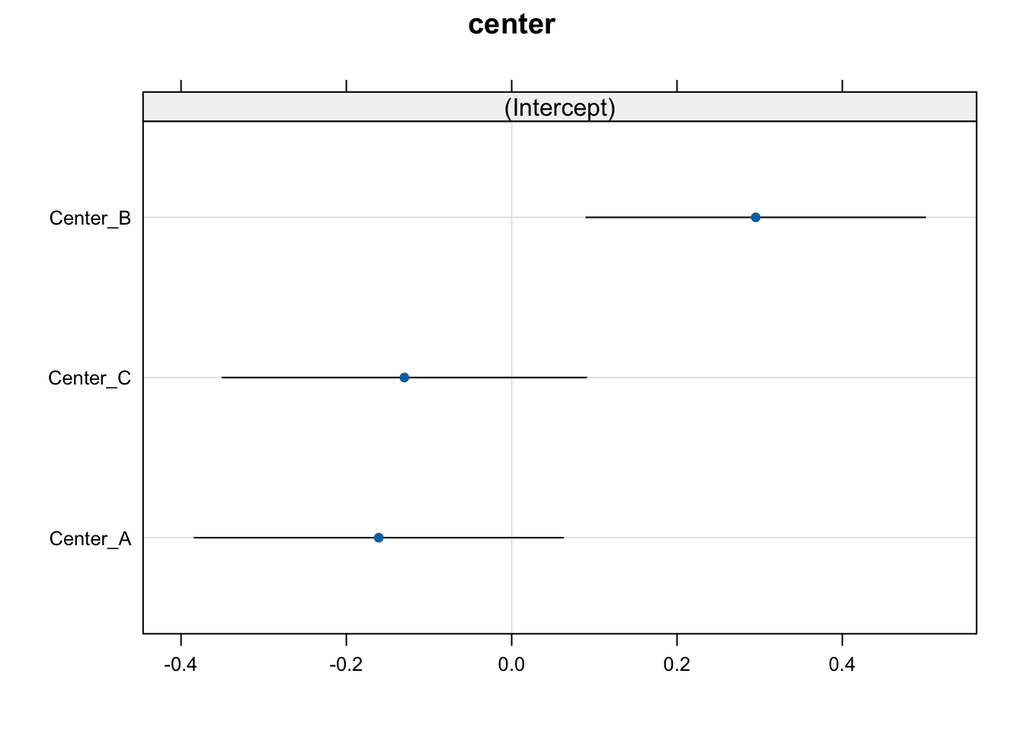

```r
dotplot(ranef(log_MEM))
```

```r
sigma2_lat <- pi^2/3
print(VarCorr(log_MEM), comp = c("Variance", "Std.Dev."))
```

```
##  Groups Name        Variance Std.Dev.
##  center (Intercept) 0.055628 0.23586
```

```r
sigma2_b <- as.numeric(get_variance_intercept(log_MEM))

VPC <- sigma2_b/(sigma2_b+sigma2_lat)
VPC
```

```
## [1] 0.01662786
```

### Interpretation

The Variance Partition Coefficient (VPC) is **`0.0166`**, indicating that only **1.66%** of the total variance in the 5-year severe event outcome is attributable to differences between clinical centers. This variation could be linked to slight discrepancies in hospital-specific factors, such as local therapeutic protocols, equipment differences, or variations in medical staff methods.

However, the remaining 98.34% of the variability is driven entirely by patient-level characteristics. This confirms a very high degree of homogeneity across institutions, meaning that a patient’s long-term prognosis depends almost entirely on their specific clinical profile rather than the hospital where they received care.

## Final Comment for Question 1

Tthe study demonstrates that long-term prognosis of Chronic Autoimmune Diseases is driven by different factors:

- **Risk Factors:** Advanced age, higher baseline inflammation, and prior relapses significantly increase the risk of a severe 5-year event.
- **Protective Factor:** A robust baseline cytokine response (`cytokine_activity_score`) is associated with better outcomes, suggesting that an effective acute immune activation is crucial for tissue healing and disease control.

Furthermore, an investigation on the random effect of the diagnosis center highlighted that the progonosis is almost entirely driven by **individual clinical profiles (98.34%)** rather than institutional differences between healthcare centers (1.66%).

# Question 2

## Assigned Exercise

#### **Question 21:**

> Study the effect of treatment strategy on progression to severe clinical outcome. The endpoint of interest is `time_to_severe_outcome`, where the event is defined as the occurrence of hospitalization or treatment failure.
> 1. Describe and compare baseline clinical characteristics between treatment groups using appropriate descriptive statistics.
> 2. Estimate Kaplan-Meier curves stratified by treatment arm and visually assess differences.
> 3. Perform a log-rank test to formally evaluate whether survival distributions differ between treatment groups.
> 4. Fit a multivariate Cox proportional hazards model including:
>    - treatment arm
>    - age
>    - sex
>    - inflammatory index
>    - steroid use
>    - prior relapse.

>    Interpret the results.
> 5. Assess whether the proportional hazards assumption is satisfied.

## Step 1

```r
patients$treatment_arm <- factor(patients$treatment_arm)
patients$sex <- factor(patients$sex, levels = c("female","male"))
```

In order to compare the baseline clinical characteristics between treatment groups (biologic or standard) two different test have been assessed. For the continuous variables, such as age and inflammatory index, the Mann-Whitney U test has been performed.

#### Age distribution (Mann-Whitney U test)

$H_0$**:** Age distribution is the same in the standard and biologic treatment arms; $H_1$**:** Age distribution differs between the two treatment arms.

```r
wilcox_age <- wilcox.test(patients[patients$treatment_arm=="biologic",]$age,
                          patients[patients$treatment_arm=="standard",]$age, paired=FALSE)
cat("Wilcoxon test age ~ treatment: p =", signif(wilcox_age$p.value, 3), "\n")
```

```
## Wilcoxon test age ~ treatment: p = 0.971
```

#### Inflammatory Index distribution (Mann-Whitney U test)

$H_0$**:** Inflammatory index distribution is the same in the standard and biologic treatment arms; $H_1$**:** Inflammatory index distribution differs between the two treatment arms.

```r
wilcox_infl <- wilcox.test(patients[patients$treatment_arm=="biologic",]$inflammatory_index,
                          patients[patients$treatment_arm=="standard",]$inflammatory_index, paired=FALSE)
cat("Wilcoxon test inflammatory index ~ treatment: p =", signif(wilcox_infl$p.value, 3), "\n")
```

```
## Wilcoxon test inflammatory index ~ treatment: p = 0.686
```

For the categorical variables, such as sex, steroid usage and prior relapse, the **Chi-squared test** has been performed but only after checking the data respect the **Cochran’s rule**:

- at least 80% of the expected frequencies exceed 5
- all the expected frequencies exceed 1

```r
compute_expected <- function(tab_obs) {
  N <- sum(tab_obs)
  Tot_row <- apply(tab_obs, 1, sum)
  Tot_col <- apply(tab_obs, 2, sum)
  Expected <- matrix(NA,nrow=2,ncol=2)
  dimnames(Expected) <- dimnames(tab_obs)
  Expected[1,1] <- Tot_row[1]*Tot_col[1]/N
  Expected[1,2] <- Tot_row[1]*Tot_col[2]/N
  Expected[2,1] <- Tot_row[2]*Tot_col[1]/N
  Expected[2,2] <- Tot_row[2]*Tot_col[2]/N
  Expected}
```

#### Sex ~ Treatment relationship (Chi-squared test)

$H_0$**:** There is no relationship or association between sex and treatment arm; $H_1$**:** There is a relationship or association of any kind between sex and treatment arm.

```r
tab_sex_obs <- table(patients$treatment_arm, df$sex)
compute_expected(tab_sex_obs)
```

```
##
##             female    male
##   biologic 225.336 266.664
##   standard 232.664 275.336
```

```r
chisq.test(tab_sex_obs, correct = F)
```

```
##
##  Pearson's Chi-squared test
##
## data:  tab_sex_obs
## X-squared = 0.17937, df = 1, p-value = 0.6719
```

#### Steroid usage ~ Treatment relationship (Chi-squared test)

$H_0$**:** There is no relationship or association between steroid usage and treatment arm; $H_1$**:** There is a relationship or association of any kind between steroid usage and treatment arm.

```r
tab_steroid_obs <- table(patients$treatment_arm, patients$steroid_use)
compute_expected(tab_steroid_obs)
```

```
##
##                  0       1
##   biologic 317.832 174.168
##   standard 328.168 179.832
```

```r
chisq.test(tab_steroid_obs, correct = F)
```

```
##
##  Pearson's Chi-squared test
##
## data:  tab_steroid_obs
## X-squared = 0.25691, df = 1, p-value = 0.6122
```

#### Prior Relapse ~ Treatment relationship (Chi-squared test)

$H_0$**:** There is no relationship or association between prior relapse and treatment arm; $H_1$**:** There is a relationship or association of any kind between prior relaps and treatment arm.

```r
tab_pr.relapse_obs <- table(patients$treatment_arm, patients$prior_relapse)
compute_expected(tab_pr.relapse_obs)
```

```
##
##                 0      1
##   biologic 300.12 191.88
##   standard 309.88 198.12
```

```r
chisq.test(tab_pr.relapse_obs, correct = F)
```

```
##
##  Pearson's Chi-squared test
##
## data:  tab_pr.relapse_obs
## X-squared = 2.3736, df = 1, p-value = 0.1234
```

### Interpretation

To evaluate baseline clinical characteristics between treatment groups (**age, sex, prior relapse, baseline steroid usage, and inflammatory index)** theywere compared between the biological treatment group and the standard treatment group using two different statistical tests.

Across the two different statistical tests performed (Mann Whitney U tests for continuous variables and Chi-squared tests for categorical variables), the resulting $p\text{-values}$ consistently fell **above the significance threshold (**$\alpha = 0.05$) for **each variable**.

Statistically, these high $p\text{-values}$ indicate a failure to reject the null hypothesis of equal distributions between the two arms. This demonstrates that there is no empirical evidence to consider the biological and standard treatment populations different regarding any of these key baseline prognostic factors. Consequently, the two cohorts can be considered **homogeneous** at study entry.

## Step 2

```r
patients$event <- as.numeric(patients$outcome_type %in% c("hospitalization", "treatment_failure"))
patients$treatment_arm <- factor(patients$treatment_arm, levels = c("biologic","standard"))

fit.treatment <- survfit(Surv(time_to_severe_outcome, event) ~ treatment_arm, data = patients)
summary(fit.treatment)$table
```

```
##                        records n.max n.start events    rmean se(rmean)   median
## treatment_arm=biologic     492   492     492    289 7.431371 0.1228895 8.105547
## treatment_arm=standard     508   508     508    362 6.552484 0.1258217 6.248502
##                         0.95LCL  0.95UCL
## treatment_arm=biologic 7.474329 9.165219
## treatment_arm=standard 5.803196 6.832510
```

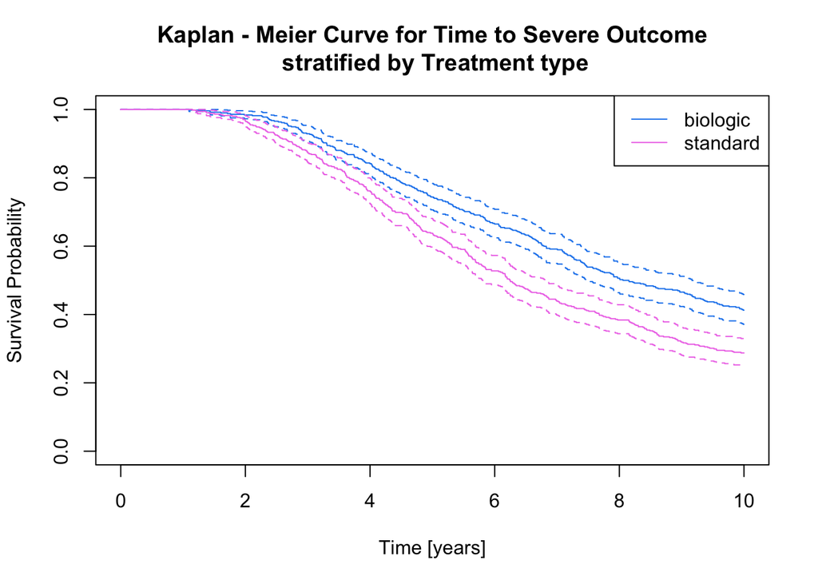

```r
plot(fit.treatment, conf.int = T, xlab='Time [years]', ylab = 'Survival Probability',
     col=c("dodgerblue2", "orchid2"), main="Kaplan - Meier Curve for Time to Severe Outcome\n stratified by Treatment type")
legend('topright', legend=c('biologic','standard'), lty=c(1,1), col=c("dodgerblue2", "orchid2"))
```

### Interpretation

The Kaplan-Meier curves stratified by treatment arm show a clear and sustained separation between the two treatment arms, with the biologic therapy group exhibiting a higher event-free survival probability than the standard therapy group from approximately year 2. By the end of the 10-year follow-up, an estimated 40% of patients on biologic therapy remained free of severe clinical outcomes, compared to approximately 28–30% of patients on standard therapy. The 95% confidence intervals around the two curves do not show important overlaps, suggesting a potential difference in survival distributions between arms. These descriptive findings are consistent with a protective effect of biologic therapy, delaying progression to a severe clinical outcome, the event, corresponding in hospitalization or treatment failure, relative to standard therapy.

This visual impression find also confirm through the median values of the two different treatment arm event time.

## Step 3

```r
survdiff(Surv(time_to_severe_outcome, event) ~ treatment_arm, data = patients)
```

```
## Call:
## survdiff(formula = Surv(time_to_severe_outcome, event) ~ treatment_arm,
##     data = patients)
##
##                          N Observed Expected (O-E)^2/E (O-E)^2/V
## treatment_arm=biologic 492      289      350      10.5      22.8
## treatment_arm=standard 508      362      301      12.2      22.8
##
##  Chisq= 22.8  on 1 degrees of freedom, p= 2e-06
```

### Interpretation

The log rank test for difference in survival gives a p-value of `p = 2e-06`, indicating that biologic and standard treatment patients differ significantly in terms of survival.

## Step 4

```r
cox_mod <- coxph(Surv(time_to_severe_outcome, event) ~ treatment_arm + age + sex +
                   inflammatory_index + steroid_use + prior_relapse, data = patients)
summary(cox_mod)
```

```
## Call:
## coxph(formula = Surv(time_to_severe_outcome, event) ~ treatment_arm +
##     age + sex + inflammatory_index + steroid_use + prior_relapse,
##     data = patients)
##
##   n= 1000, number of events= 651
##
##                            coef exp(coef)  se(coef)      z Pr(>|z|)
## treatment_armstandard  0.371188  1.449456  0.079316  4.680 2.87e-06 ***
## age                    0.028925  1.029348  0.003087  9.369  < 2e-16 ***
## sexmale               -0.054689  0.946780  0.079553 -0.687 0.491800
## inflammatory_index     0.199829  1.221194  0.022930  8.715  < 2e-16 ***
## steroid_use            0.130681  1.139604  0.081410  1.605 0.108446
## prior_relapse          0.272243  1.312905  0.079752  3.414 0.000641 ***
## ---
## Signif. codes:  0 '***' 0.001 '**' 0.01 '*' 0.05 '.' 0.1 ' ' 1
##
##                       exp(coef) exp(-coef) lower .95 upper .95
## treatment_armstandard    1.4495     0.6899    1.2408     1.693
## age                      1.0293     0.9715    1.0231     1.036
## sexmale                  0.9468     1.0562    0.8101     1.107
## inflammatory_index       1.2212     0.8189    1.1675     1.277
## steroid_use              1.1396     0.8775    0.9715     1.337
## prior_relapse            1.3129     0.7617    1.1229     1.535
##
## Concordance= 0.656  (se = 0.011 )
## Likelihood ratio test= 185.7  on 6 df,   p=<2e-16
## Wald test            = 178.9  on 6 df,   p=<2e-16
## Score (logrank) test = 180.7  on 6 df,   p=<2e-16
```

### Interpretation

- $H_0$: $\beta_1 = \beta_2 = \dots = \beta_k = 0$ None of the covariates are associated with survival time, they’re all equal;
- $H_1$: $\beta_j \neq 0$ At least one covariate in the model is significantly associated with the hazard of the event, indicating the model provides a significantly better fit than a null model.

The p-value for all three overall tests (likelihood, Wald, and score) are highly significant ($p < 2\times10^{-16}$), indicating that at least one of the covariates in the model is significant and the test statistics above are in close agreement, and the omnibus null hypothesis that all of the betas are 0 is rejected.

In the multivariate Cox analysis, the covariates **treatment_armstandard**, **age**, **inflammatory_index**, and **prior_relapse** are significant ($p < 0.05$). However, the covariates **sexmale** and **steroid_use** fail to be significant.

The hazard ratios of covariates are interpretable as multiplicative effects on the hazard.

- The HR for **treatment_arm standard** is $\exp(\text{coef}) = 1.45$ with 95% CI = $[1.24; 1.69]$. Holding the other covariates constant, undergoing a standard treatment compared to a biological treatment increases the risk of a severe disease outcome by 45%. So, receiving the standard treatment is associated with a worse prognosis.
- The HR for **age** is $\exp(\text{coef}) = 1.03$ with 95% CI = $[1.02; 1.04]$, indicating a relationship between age and the risk of a severe outcome. Holding the other covariates constant, each additional year of age increases the risk of a severe event by approximately 3%, associating an older age with a worse survival.
- The HR for **inflammatory_index** is $\exp(\text{coef}) = 1.22$ with 95% CI = $[1.17; 1.28]$. Holding the other covariates constant, a higher baseline value of the inflammatory index is significantly associated with an increased risk of a severe event and a worse prognosis.
- The HR for **prior_relapse** is $\exp(\text{coef}) = 1.31$ with 95% CI = $[1.12; 1.54]$, indicating that patients with a history of prior relapses have a 31% higher risk of experiencing a severe outcome compared to those without, holding the other covariates constant.
- The hazard ratio HR of **sexmale** is $\exp(\text{coef}) = 0.95$, with a 95% CI = $[0.81; 1.11]$. Because the confidence interval for HR includes 1, these results indicate that biological sex makes a smaller, non-statistically significant contribution to the difference in survival after adjusting for other covariates.
- Similarly, the hazard ratio HR of **steroid_use** is $\exp(\text{coef}) = 1.14$, with a 95% CI = $[0.97; 1.34]$. Because the confidence interval for HR includes 1, these results indicate that baseline steroid usage makes a smaller, non-statistically significant contribution to the difference in survival after adjusting for other covariates.

## Step 5

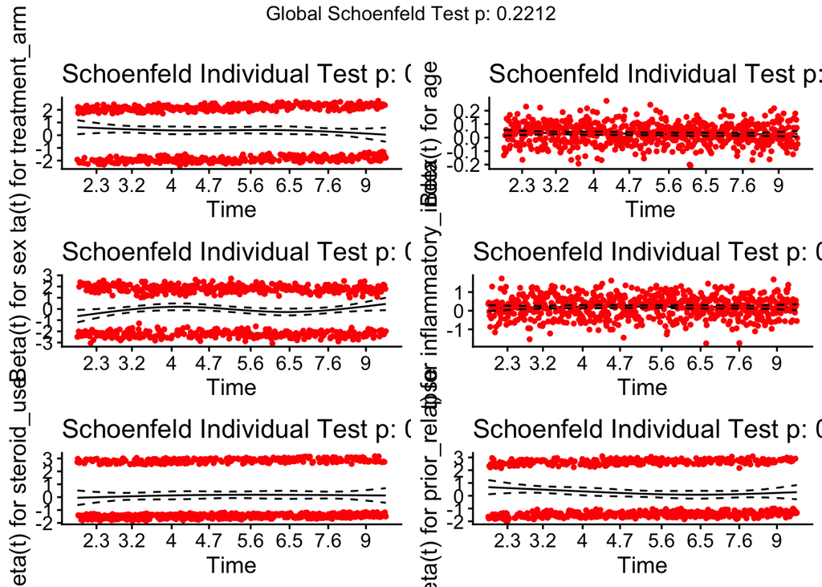

```r
diag.ph <- cox.zph(cox_mod)
ggcoxzph(diag.ph)
```

Schoenfeld residuals represent the difference between the observed covariate and the expected given the risk set at that time. They should be flat, centered about zero. The Schoenfeld residuals should be independent of time. A plot that shows a non-random pattern against time is evidence of violation of the PH assumption. We can use the `cox.zph()` from the survival package:

```r
diag.ph
```

```
##                    chisq df     p
## treatment_arm      2.023  1 0.155
## age                1.418  1 0.234
## sex                1.104  1 0.293
## inflammatory_index 0.454  1 0.500
## steroid_use        0.320  1 0.572
## prior_relapse      3.204  1 0.073
## GLOBAL             8.238  6 0.221
```

### Interpretation

From the output above, the global test isn’t statistically significant. Therefore, we can assume the proportional hazards for all covariate since there are no reasons to reject the null hypothesis.

These findings indicate a **failure to reject the null hypothesis** of proportional hazards, confirming that the relative risks between treatment recieved remain constant and independent of time. Therefore, the proportional hazards assumption is fully satisfied by a non-significant relationship between residuals and time, ensuring that the previously estimated hazard ratios are robust, valid, and reliable for clinical interpretation.

## Final Comment for Question 2

Treatment strategy has a clear, clinically meaningful effect on progression to severe disease activity: patients on standard therapy show a significantly higher risk than those on biologic therapy (HR = 1.45, 95% CI [1.24; 1.69]), confirmed both by the Kaplan-Meier curves and the log-rank test (p = 2×10⁻⁶).

In the multivariate Cox model, age, inflammatory index, and prior relapse remained independent risk factors, while sex and steroid use were not significant (CIs including 1) — consistent with Question 1.

Since baseline characteristics were homogeneous between arms (all p > 0.05), the survival difference can be attributed to treatment itself rather than confounding, and the proportional hazards assumption was verified (global p = 0.221), supporting the robustness of these estimates. Overall, biologic therapy emerges as the preferable strategy for reducing the risk of severe disease progression.